# Milestone 2

#### Lorraine Steigner | Fall 2023

https://llsteigner.github.io/cmps6790/

For my project I decided to examine trends in the place of origin (fabric) vs the location of where ceramics have been excavated in the Classical world (so the Mediterranean region, primarily). While taking the *Etruscans and Early Rome* course we talked a lot about how Greek workshops were making pots in Athens but specifically in Etruscan styles to be exported, and I became interested in examining what made people favor Greek-produced Etruscan-styled pottery over, say, Etruscan-produced Etruscan style pottery-- and then more generally, what makes the people in a site favor foriegn pottery, which is more expensive and harder to obtain?

The primary dataset is the Beazley Archive Pottery Database (BAPD), collected and maintained through the Oxford University Classical Art Research Center. The BAPD contains data on ceramic fabric (origin), location found, style of pot, and estimated dating of the ceramic, among others. [https://www.carc.ox.ac.uk/XDB/ASP/searchOpen.asp]

I was unsatisfied with the BAPD location data so I correlated it with data from the Pleiades location data. (This is still a work in progress and I'm considering shifting to another location dataset because the Pleiades one also had lots of names-- but I will still have to use Pleiades for the BAPD entries without a name.) I specifically used the **location** dataset as opposed to the **place** dataset because only the location dataset contains data for real world sites and has latitude and longitude recorded. Places can have a location and locations can have a place but its not one-to-one; Atlantis is an ancient place without a recorded location (because it doesn't exist) and there are archaeological sites at locations that haven't been correlated with a known ancient place. [https://pleiades.stoa.org/] [[https://github.com/isawnyu/pleiades.datasets/tree/main/data/csv]\](https://github.com/isawnyu/pleiades.datasets/tree/main/data/csv%5D%5C)

I hoped to use a dataset of ancient ports but it was not publically available and I haven't been granted access yet. :(

In the process of cleaning the data and generating some early graphs I realised that I needed to also be considering the dating of an object, since sociopolitical events in the classical world will of course impact the rate of export/import for pottery. For example, during the Peloponessian War Athenian potters will be less concerned with sending pots to Italy...

Moving forward, for the final, I aim to:

- Rework how I structure the location data
- Be able to generate maps (geopandas time...)
- Bring in other pot datasets (like from [https://archaeologydataservice.ac.uk/archives/view/hayton_eh_2007/downloads_data.cfm] and [https://arachne.dainst.org/], will also probably have to scrape data from museum websites...
- Factor in time data

And generate models that:

- Predict the ratio of local pottery vs imported pottery based off location data, time data, and population(?) data | regression model
- Predict the origin of imported pottery | classification model

```python
import pandas as pd
import numpy as np
import re
import matplotlib.pyplot as plt
import urllib.request
from urllib.parse import urlparse
from bs4 import BeautifulSoup
```

# BAPD

```python
bapd = pd.read_csv("bapd_pots.csv")
```

```python
display(bapd)
```

|  | URI | Vase Number | Fabric | Technique | Sub Technique | Shape Name | Provenance | Date | Inscriptions | Attributed To | ... | Technical Observations | Image Credits | Pleiades URI | Latitude | Longitude | LIMC ID | LIMC Web | British Museum Link | Ure Museum Link | Bryn Mawr College Link |
| --- | --- | --- | --- | --- | --- | --- | --- | --- | --- | --- | --- | --- | --- | --- | --- | --- | --- | --- | --- | --- | --- |
| 0 | http://www.beazley.ox.ac.uk/record/AA1CD952-92... | 1.0 | ATHENIAN | BLACK-FIGURE | NaN | AMPHORA, NECK | ITALY, ETRURIA, VULCI | -525 to -475 | NaN | CHIUSI P by KUNZE-GOTTE \| LEAGROS GROUP by KUN... | ... | NaN | NaN | https://pleiades.stoa.org/places/413393 | 42.421429 | 11.702499 | 6368 | http://ark.dasch.swiss/ark:/72163/080e-73fdcff... | NaN | NaN | NaN |
| 1 | http://www.beazley.ox.ac.uk/record/85D73CAF-DC... | 2.0 | ATHENIAN | BLACK-FIGURE | NaN | KRATER, COLUMN FRAGMENT | GREECE, ATHENS, AGORA | -550 to -500 | NaN | NaN | ... | NaN | NaN | NaN | NaN | NaN | NaN | NaN | NaN | NaN | NaN |
| 2 | http://www.beazley.ox.ac.uk/record/B7867649-B6... | 3.0 | ATHENIAN | BLACK-FIGURE | NaN | AMPHORA, NECK | ITALY, ETRURIA, VULCI | -550 to -500 | NaN | NaN | ... | NaN | NaN | https://pleiades.stoa.org/places/413393 | 42.421429 | 11.702499 | 1023 | http://ark.dasch.swiss/ark:/72163/080e-73b1f46... | NaN | NaN | NaN |
| 3 | http://www.beazley.ox.ac.uk/record/64B75012-4B... | 4.0 | ATHENIAN | BLACK-FIGURE | NaN | AMPHORA, NECK | NaN | -550 to -500 | NaN | <em>Near</em> MEDEA GROUP by UNKNOWN | ... | NaN | NaN | NaN | NaN | NaN | 1009 | http://ark.dasch.swiss/ark:/72163/080e-73b1c12... | NaN | NaN | NaN |
| 4 | http://www.beazley.ox.ac.uk/record/ED45A6A0-5C... | 5.0 | ATHENIAN | BLACK-FIGURE | NaN | AMPHORA, NECK | NaN | -525 to -475 | NaN | ANTIMENEAN by KUNZE-GOTTE \| DAYBREAK P by POUI... | ... | NaN | NaN | NaN | NaN | NaN | 10571 | http://ark.dasch.swiss/ark:/72163/080e-74394cd... | https://www.britishmuseum.org/collection/objec... | NaN | NaN |
| ... | ... | ... | ... | ... | ... | ... | ... | ... | ... | ... | ... | ... | ... | ... | ... | ... | ... | ... | ... | ... | ... |
| 131192 | http://www.beazley.ox.ac.uk/record/C7AFB93A-48... | 9053423.0 | ATHENIAN | RED-FIGURE | NaN | CUP FRAGMENT | NaN | -500 to -450 | NaN | NaN | ... | NaN | NaN | NaN | NaN | NaN | NaN | NaN | NaN | NaN | NaN |
| 131193 | http://www.beazley.ox.ac.uk/record/49E67A19-A2... | 9053424.0 | ATHENIAN | RED-FIGURE | NaN | CUP FRAGMENT | NaN | -500 to -450 | NaN | CLINIC P by BOTHMER | ... | NaN | NaN | NaN | NaN | NaN | NaN | NaN | NaN | NaN | NaN |
| 131194 | http://www.beazley.ox.ac.uk/record/8D202FC3-F4... | 9053425.0 | ATHENIAN | RED-FIGURE | NaN | CUP FRAGMENT | NaN | -500 to -450 | NaN | NaN | ... | NaN | NaN | NaN | NaN | NaN | NaN | NaN | NaN | NaN | NaN |
| 131195 | http://www.beazley.ox.ac.uk/record/E0421614-B6... | 9053426.0 | ATHENIAN | RED-FIGURE | NaN | CUP FRAGMENT | NaN | -525 to -475 | NaN | <em>School of</em> MAKRON by BOTHMER | ... | NaN | NaN | NaN | NaN | NaN | NaN | NaN | NaN | NaN | NaN |
| 131196 | http://www.beazley.ox.ac.uk/record/198FC69F-91... | 9053427.0 | ATHENIAN | RED-FIGURE | NaN | CUP FRAGMENT | NaN | -525 to -475 | NaN | NaN | ... | NaN | NaN | NaN | NaN | NaN | NaN | NaN | NaN | NaN | NaN |

131197 rows × 29 columns

## COLUMN CLEANUP

```python
bapd.columns # check column names-- too many to easily read on screen
```

```
Index(['URI', 'Vase Number', 'Fabric', 'Technique', 'Sub Technique',
       'Shape Name', 'Provenance', 'Date', 'Inscriptions', ' Attributed To',
       ' Decoration', ' Collection Record', ' Publication Record',
       ' Inscriptions II', 'Measurements', 'Volume', 'Weight', 'Restorations',
       'Ornament', ' Technical Observations', 'Image Credits', 'Pleiades URI',
       'Latitude', 'Longitude', 'LIMC ID', 'LIMC Web', 'British Museum Link',
       'Ure Museum Link', 'Bryn Mawr College Link'],
      dtype='object')
```

```python
bapd.rename(columns = {' Attributed To':'Attributed To',
                     ' Decoration':'Decoration',
                     ' Collection Record':'Collection Record',
                     ' Publication Record':'Publication Record',
                     ' Inscriptions II':'Inscriptions II',
                     ' Technical Observations':'Technical Observations'}, inplace = True)
```

Since right now I'm only dealing with the single database, I remove any columns that are entirely empty.

Incidentally, those columns were:

- Inscriptions II
- Volume
- Weight
- Restorations
- Ornament
- Technical Observations

```python
for column in bapd:
    tech = bapd[[column]].dropna()
    if tech.empty:
        #print(column)
        del bapd[column]
```

The BAPD dataset very nicely contains a lot of links to relevant records in other databases. I want to use these eventually (especially to fill in missing data) but not in this milestone. I make a copy of the database with only the columns linking to other databases, to come back and reference later-- the indicies will be preserved for a one-to-one record.

```python
bapd['Fabric'].value_counts()
```

```
Fabric
ATHENIAN                  102468
SOUTH ITALIAN, APULIAN      3400
CORINTHIAN                  3051
ETRUSCAN                    2139
ATHENIAN GEOMETRIC          2093
                           ...
APULIAN GEOMETRIC              1
ARADAC                         1
MESOPOTAMIAN                   1
STARCEVO                       1
GRADAC                         1
Name: count, Length: 177, dtype: int64
```

```python
#df["Sub Technique"].unique
```

```python
links = bapd[['URI',
            'Collection Record', # what museum is the piece in now?
            'Publication Record', # what journal/article/etc. was the piece documented in?
            'Pleiades URI',
            'LIMC ID',
            'LIMC Web',
            'British Museum Link',
            'Ure Museum Link',
            'Bryn Mawr College Link']]
links.head()
```

|  | URI | Collection Record | Publication Record | Pleiades URI | LIMC ID | LIMC Web | British Museum Link | Ure Museum Link | Bryn Mawr College Link |
| --- | --- | --- | --- | --- | --- | --- | --- | --- | --- |
| 0 | http://www.beazley.ox.ac.uk/record/AA1CD952-92... | Munich, Antikensammlungen: J543 \| Rome, Candel... | Corpus Vasorum Antiquorum: MUNICH, MUSEUM ANTI... | https://pleiades.stoa.org/places/413393 | 6368 | http://ark.dasch.swiss/ark:/72163/080e-73fdcff... | NaN | NaN | NaN |
| 1 | http://www.beazley.ox.ac.uk/record/85D73CAF-DC... | Athens, Agora Museum: P13332 | The Athenian Agora, Results of Excavations con... | NaN | NaN | NaN | NaN | NaN | NaN |
| 2 | http://www.beazley.ox.ac.uk/record/B7867649-B6... | Rome, Mus. Naz. Etrusco di Villa Giulia: 63614 | Jahrbuch des Deutschen Archäologischen Institu... | https://pleiades.stoa.org/places/413393 | 1023 | http://ark.dasch.swiss/ark:/72163/080e-73b1f46... | NaN | NaN | NaN |
| 3 | http://www.beazley.ox.ac.uk/record/64B75012-4B... | Budapest, Hungarian Museum of Fine Arts: 50.732 | Bulletin du Musee Hongrois des Beaux-Arts, Bud... | NaN | 1009 | http://ark.dasch.swiss/ark:/72163/080e-73b1c12... | NaN | NaN | NaN |
| 4 | http://www.beazley.ox.ac.uk/record/ED45A6A0-5C... | London, British Museum: B240 \| Rome, market, B... | Barringer, J.M., Divine Escorts, Nereids in Ar... | NaN | 10571 | http://ark.dasch.swiss/ark:/72163/080e-74394cd... | https://www.britishmuseum.org/collection/objec... | NaN | NaN |

Now since I've moved all my links into a separate dataframe I remove those columns from the original:

```python
bapd = bapd.drop(['URI',
            'Collection Record', # what museum is the piece in now?
            'Publication Record', # what journal/article/etc. was the piece documented in?
            'LIMC ID',
            'LIMC Web',
            'British Museum Link',
            'Ure Museum Link',
            'Bryn Mawr College Link'],
            axis=1)
bapd.columns
```

```
Index(['Vase Number', 'Fabric', 'Technique', 'Sub Technique', 'Shape Name',
       'Provenance', 'Date', 'Inscriptions', 'Attributed To', 'Decoration',
       'Measurements', 'Image Credits', 'Pleiades URI', 'Latitude',
       'Longitude'],
      dtype='object')
```

```python
bapd.head()
```

|  | Vase Number | Fabric | Technique | Sub Technique | Shape Name | Provenance | Date | Inscriptions | Attributed To | Decoration | Measurements | Image Credits | Pleiades URI | Latitude | Longitude |
| --- | --- | --- | --- | --- | --- | --- | --- | --- | --- | --- | --- | --- | --- | --- | --- |
| 0 | 1.0 | ATHENIAN | BLACK-FIGURE | NaN | AMPHORA, NECK | ITALY, ETRURIA, VULCI | -525 to -475 | NaN | CHIUSI P by KUNZE-GOTTE \| LEAGROS GROUP by KUN... | A,B: TRIPTOLEMOS ON WINGED CHARIOT BETWEEN DEM... | NaN | NaN | https://pleiades.stoa.org/places/413393 | 42.421429 | 11.702499 |
| 1 | 2.0 | ATHENIAN | BLACK-FIGURE | NaN | KRATER, COLUMN FRAGMENT | GREECE, ATHENS, AGORA | -550 to -500 | NaN | NaN | Under handle: VOLUTE KRATER | NaN | NaN | NaN | NaN | NaN |
| 2 | 3.0 | ATHENIAN | BLACK-FIGURE | NaN | AMPHORA, NECK | ITALY, ETRURIA, VULCI | -550 to -500 | NaN | NaN | A,B: TRIPTOLEMOS AND DEMETER | NaN | NaN | https://pleiades.stoa.org/places/413393 | 42.421429 | 11.702499 |
| 3 | 4.0 | ATHENIAN | BLACK-FIGURE | NaN | AMPHORA, NECK | NaN | -550 to -500 | NaN | <em>Near</em> MEDEA GROUP by UNKNOWN | A: TRIPTOLEMOS SEATED ON CART WITH SHEAVES OF ... | NaN | NaN | NaN | NaN | NaN |
| 4 | 5.0 | ATHENIAN | BLACK-FIGURE | NaN | AMPHORA, NECK | NaN | -525 to -475 | NaN | ANTIMENEAN by KUNZE-GOTTE \| DAYBREAK P by POUI... | A: WINGED WARRIOR RUNNING OVER SEA WITH FISH A... | NaN | NaN | NaN | NaN | NaN |

I still have a few columns that aren't really relevant to what I'm looking for today-- I'm only worried about **style** and **location** data right now.

I remove the columns not clearly related to location and/or stylistic movements.

```python
bapd = bapd.drop(['Decoration',
            'Inscriptions',
            'Measurements',
            'Shape Name',
            'Sub Technique',
            'Attributed To', # BRING THIS BACK LATER ITS IMPORTANT
            'Image Credits'],
            axis=1)
bapd.columns
```

```
Index(['Vase Number', 'Fabric', 'Technique', 'Provenance', 'Date',
       'Pleiades URI', 'Latitude', 'Longitude'],
      dtype='object')
```

```python
display(bapd)
```

|  | Vase Number | Fabric | Technique | Provenance | Date | Pleiades URI | Latitude | Longitude |
| --- | --- | --- | --- | --- | --- | --- | --- | --- |
| 0 | 1.0 | ATHENIAN | BLACK-FIGURE | ITALY, ETRURIA, VULCI | -525 to -475 | https://pleiades.stoa.org/places/413393 | 42.421429 | 11.702499 |
| 1 | 2.0 | ATHENIAN | BLACK-FIGURE | GREECE, ATHENS, AGORA | -550 to -500 | NaN | NaN | NaN |
| 2 | 3.0 | ATHENIAN | BLACK-FIGURE | ITALY, ETRURIA, VULCI | -550 to -500 | https://pleiades.stoa.org/places/413393 | 42.421429 | 11.702499 |
| 3 | 4.0 | ATHENIAN | BLACK-FIGURE | NaN | -550 to -500 | NaN | NaN | NaN |
| 4 | 5.0 | ATHENIAN | BLACK-FIGURE | NaN | -525 to -475 | NaN | NaN | NaN |
| ... | ... | ... | ... | ... | ... | ... | ... | ... |
| 131192 | 9053423.0 | ATHENIAN | RED-FIGURE | NaN | -500 to -450 | NaN | NaN | NaN |
| 131193 | 9053424.0 | ATHENIAN | RED-FIGURE | NaN | -500 to -450 | NaN | NaN | NaN |
| 131194 | 9053425.0 | ATHENIAN | RED-FIGURE | NaN | -500 to -450 | NaN | NaN | NaN |
| 131195 | 9053426.0 | ATHENIAN | RED-FIGURE | NaN | -525 to -475 | NaN | NaN | NaN |
| 131196 | 9053427.0 | ATHENIAN | RED-FIGURE | NaN | -525 to -475 | NaN | NaN | NaN |

131197 rows × 8 columns

## Reformatting

Since all the dates for these artifacts are estimates, I will separate the Date column into two columns-- the upper estimate for when the piece was made and the lower estimate for when the piece was made.

There are two anomalies in the date formatting, and both deal with only one date being given. In both cases I simply duplicate the date that *is* given-- this means the earliest date and the latest date will be identical for now.

Then I just split the Date string into the earlier and later dates and add to their respective columns. I delete the original date column when I'm done.

```python
# making the new columns
bapd.insert(7, 'Earliest Date', np.nan)
bapd.insert(8, 'Latest Date', np.nan)
```

```python
for i, date in bapd["Date"].items(): # loop over rows in Date Column
    if not pd.isnull(date):
        if ( "to" not in str(date) ) or ( len(date.split(" to ")) ) == 1: # two anomalies in format: either listed as a single  or date == " to -300"
            date = re.sub('[a-zA-Z]', '', str(date)).strip()
            bapd.at[i,"Date"] = f"{date} to {date}"
        dates = bapd.at[i,"Date"].split(" to ")
        bapd.at[i,'Earliest Date'] = dates[0]
        bapd.at[i,'Latest Date'] = dates[1]
```

## LATITUDE AND LONGITUDE

```python
bapd = bapd.dropna(axis=0, subset=['Provenance']) # get rid of rows w no location data
```

```python
display(bapd)
```

|  | Vase Number | Fabric | Technique | Provenance | Date | Pleiades URI | Latitude | Earliest Date | Latest Date | Longitude |
| --- | --- | --- | --- | --- | --- | --- | --- | --- | --- | --- |
| 0 | 1.0 | ATHENIAN | BLACK-FIGURE | ITALY, ETRURIA, VULCI | -525 to -475 | https://pleiades.stoa.org/places/413393 | 42.421429 | -525 | -475 | 11.702499 |
| 1 | 2.0 | ATHENIAN | BLACK-FIGURE | GREECE, ATHENS, AGORA | -550 to -500 | NaN | NaN | -550 | -500 | NaN |
| 2 | 3.0 | ATHENIAN | BLACK-FIGURE | ITALY, ETRURIA, VULCI | -550 to -500 | https://pleiades.stoa.org/places/413393 | 42.421429 | -550 | -500 | 11.702499 |
| 10 | 12.0 | ATHENIAN | BLACK-FIGURE | GREECE, ATHENS, AGORA | -300 to -200 | NaN | NaN | -300 | -200 | NaN |
| 19 | 22.0 | ATHENIAN | RED-FIGURE | GREECE, AEGINA | -450 to -400 | NaN | NaN | -450 | -400 | NaN |
| ... | ... | ... | ... | ... | ... | ... | ... | ... | ... | ... |
| 131169 | 9053400.0 | ATHENIAN | BLACK-FIGURE | UKRAINE, BEREZAN | -575 to -525 | https://pleiades.stoa.org/places/228775 | 46.629636 | -575 | -525 | 31.484070 |
| 131170 | 9053401.0 | ATHENIAN | BLACK-FIGURE | UKRAINE, BEREZAN | -575 to -525 | https://pleiades.stoa.org/places/228775 | 46.629636 | -575 | -525 | 31.484070 |
| 131171 | 9053402.0 | ATHENIAN | BLACK-FIGURE | UKRAINE, BEREZAN | -575 to -525 | https://pleiades.stoa.org/places/228775 | 46.629636 | -575 | -525 | 31.484070 |
| 131172 | 9053403.0 | ATHENIAN | BLACK-FIGURE | UKRAINE, BEREZAN | -575 to -525 | https://pleiades.stoa.org/places/228775 | 46.629636 | -575 | -525 | 31.484070 |
| 131173 | 9053404.0 | ATHENIAN | BLACK-FIGURE | UKRAINE, BEREZAN | -575 to -525 | https://pleiades.stoa.org/places/228775 | 46.629636 | -575 | -525 | 31.484070 |

54770 rows × 10 columns

```python
display(bapd)
```

|  | Vase Number | Fabric | Technique | Provenance | Date | Pleiades URI | Latitude | Earliest Date | Latest Date | Longitude |
| --- | --- | --- | --- | --- | --- | --- | --- | --- | --- | --- |
| 0 | 1.0 | ATHENIAN | BLACK-FIGURE | ITALY, ETRURIA, VULCI | -525 to -475 | https://pleiades.stoa.org/places/413393 | 42.421429 | -525 | -475 | 11.702499 |
| 1 | 2.0 | ATHENIAN | BLACK-FIGURE | GREECE, ATHENS, AGORA | -550 to -500 | NaN | NaN | -550 | -500 | NaN |
| 2 | 3.0 | ATHENIAN | BLACK-FIGURE | ITALY, ETRURIA, VULCI | -550 to -500 | https://pleiades.stoa.org/places/413393 | 42.421429 | -550 | -500 | 11.702499 |
| 10 | 12.0 | ATHENIAN | BLACK-FIGURE | GREECE, ATHENS, AGORA | -300 to -200 | NaN | NaN | -300 | -200 | NaN |
| 19 | 22.0 | ATHENIAN | RED-FIGURE | GREECE, AEGINA | -450 to -400 | NaN | NaN | -450 | -400 | NaN |
| ... | ... | ... | ... | ... | ... | ... | ... | ... | ... | ... |
| 131169 | 9053400.0 | ATHENIAN | BLACK-FIGURE | UKRAINE, BEREZAN | -575 to -525 | https://pleiades.stoa.org/places/228775 | 46.629636 | -575 | -525 | 31.484070 |
| 131170 | 9053401.0 | ATHENIAN | BLACK-FIGURE | UKRAINE, BEREZAN | -575 to -525 | https://pleiades.stoa.org/places/228775 | 46.629636 | -575 | -525 | 31.484070 |
| 131171 | 9053402.0 | ATHENIAN | BLACK-FIGURE | UKRAINE, BEREZAN | -575 to -525 | https://pleiades.stoa.org/places/228775 | 46.629636 | -575 | -525 | 31.484070 |
| 131172 | 9053403.0 | ATHENIAN | BLACK-FIGURE | UKRAINE, BEREZAN | -575 to -525 | https://pleiades.stoa.org/places/228775 | 46.629636 | -575 | -525 | 31.484070 |
| 131173 | 9053404.0 | ATHENIAN | BLACK-FIGURE | UKRAINE, BEREZAN | -575 to -525 | https://pleiades.stoa.org/places/228775 | 46.629636 | -575 | -525 | 31.484070 |

54770 rows × 10 columns

I have latitude-longitude data for ~30,000 entries which is SWEET

```python
bapd.isna().sum()
```

```
Vase Number          0
Fabric               3
Technique         1690
Provenance           0
Date              5082
Pleiades URI     24923
Latitude         24923
Earliest Date     5082
Latest Date       5082
Longitude        24923
dtype: int64
```

```python
#I drop the latitude-longitude data here for ease. I am interested in later extracting it for sites without it from other sources... but not today...
bapd = bapd.dropna(axis=0, subset=['Latitude', 'Longitude']) # get rid of rows w no location data
display(bapd)
```

|  | Vase Number | Fabric | Technique | Provenance | Date | Pleiades URI | Latitude | Earliest Date | Latest Date | Longitude |
| --- | --- | --- | --- | --- | --- | --- | --- | --- | --- | --- |
| 0 | 1.0 | ATHENIAN | BLACK-FIGURE | ITALY, ETRURIA, VULCI | -525 to -475 | https://pleiades.stoa.org/places/413393 | 42.421429 | -525 | -475 | 11.702499 |
| 2 | 3.0 | ATHENIAN | BLACK-FIGURE | ITALY, ETRURIA, VULCI | -550 to -500 | https://pleiades.stoa.org/places/413393 | 42.421429 | -550 | -500 | 11.702499 |
| 22 | 25.0 | ATHENIAN | BLACK-FIGURE | ITALY, ETRURIA, CERVETERI | -550 to -500 | https://pleiades.stoa.org/places/422859 | 41.992798 | -550 | -500 | 12.092428 |
| 30 | 33.0 | ATHENIAN | BLACK-FIGURE | EGYPT, NAUCRATIS | -550 to -500 | https://pleiades.stoa.org/places/727169 | 30.954058 | -550 | -500 | 30.522766 |
| 35 | 38.0 | ATHENIAN | BLACK-FIGURE | ITALY, ETRURIA, TARQUINIA | -550 to -500 | https://pleiades.stoa.org/places/413332 | 42.254315 | -550 | -500 | 11.759148 |
| ... | ... | ... | ... | ... | ... | ... | ... | ... | ... | ... |
| 131169 | 9053400.0 | ATHENIAN | BLACK-FIGURE | UKRAINE, BEREZAN | -575 to -525 | https://pleiades.stoa.org/places/228775 | 46.629636 | -575 | -525 | 31.484070 |
| 131170 | 9053401.0 | ATHENIAN | BLACK-FIGURE | UKRAINE, BEREZAN | -575 to -525 | https://pleiades.stoa.org/places/228775 | 46.629636 | -575 | -525 | 31.484070 |
| 131171 | 9053402.0 | ATHENIAN | BLACK-FIGURE | UKRAINE, BEREZAN | -575 to -525 | https://pleiades.stoa.org/places/228775 | 46.629636 | -575 | -525 | 31.484070 |
| 131172 | 9053403.0 | ATHENIAN | BLACK-FIGURE | UKRAINE, BEREZAN | -575 to -525 | https://pleiades.stoa.org/places/228775 | 46.629636 | -575 | -525 | 31.484070 |
| 131173 | 9053404.0 | ATHENIAN | BLACK-FIGURE | UKRAINE, BEREZAN | -575 to -525 | https://pleiades.stoa.org/places/228775 | 46.629636 | -575 | -525 | 31.484070 |

29847 rows × 10 columns

## LOCATION

```python
# adding new columns

bapd.insert(6, 'Country', np.nan)
bapd.insert(7, 'Region', np.nan)
bapd.insert(8, 'Site', np.nan)
bapd.insert(9, 'Site, specific', np.nan)

#df.head()
```

```python
columns = ["Country", "Region", "Site", "Site, specific"]

for i, location in bapd["Provenance"].items(): # loop through the entire provenance column with location data

    if not pd.isnull(location):
        location = re.sub('[^a-zA-Z\d\s,]', '', location).strip() # keep only alphabetic characters and commas
        location = location.split(",") # split into descending sites

        for j, column in enumerate(columns): # go through the new columns in order and add each location in order
            if j + 1 > len(location): # makes sure the "add to columns" loop only runs while index present in both columns and location lists
                break
            elif j <= 3: # for the first three columns only add one piece of data
                bapd.at[i, column] = location[j].strip()
            else: # if the location gets very specific just place all the higher specifications into the "specific" column. I didn't want to have 5-7 columns for the few cases with 7 locations listed
                bapd.at[i, column] = location[j:]
```

```python
display(bapd)
```

|  | Vase Number | Fabric | Technique | Provenance | Date | Pleiades URI | Country | Region | Site | Site, specific | Latitude | Earliest Date | Latest Date | Longitude |
| --- | --- | --- | --- | --- | --- | --- | --- | --- | --- | --- | --- | --- | --- | --- |
| 0 | 1.0 | ATHENIAN | BLACK-FIGURE | ITALY, ETRURIA, VULCI | -525 to -475 | https://pleiades.stoa.org/places/413393 | ITALY | ETRURIA | VULCI | NaN | 42.421429 | -525 | -475 | 11.702499 |
| 2 | 3.0 | ATHENIAN | BLACK-FIGURE | ITALY, ETRURIA, VULCI | -550 to -500 | https://pleiades.stoa.org/places/413393 | ITALY | ETRURIA | VULCI | NaN | 42.421429 | -550 | -500 | 11.702499 |
| 22 | 25.0 | ATHENIAN | BLACK-FIGURE | ITALY, ETRURIA, CERVETERI | -550 to -500 | https://pleiades.stoa.org/places/422859 | ITALY | ETRURIA | CERVETERI | NaN | 41.992798 | -550 | -500 | 12.092428 |
| 30 | 33.0 | ATHENIAN | BLACK-FIGURE | EGYPT, NAUCRATIS | -550 to -500 | https://pleiades.stoa.org/places/727169 | EGYPT | NAUCRATIS | NaN | NaN | 30.954058 | -550 | -500 | 30.522766 |
| 35 | 38.0 | ATHENIAN | BLACK-FIGURE | ITALY, ETRURIA, TARQUINIA | -550 to -500 | https://pleiades.stoa.org/places/413332 | ITALY | ETRURIA | TARQUINIA | NaN | 42.254315 | -550 | -500 | 11.759148 |
| ... | ... | ... | ... | ... | ... | ... | ... | ... | ... | ... | ... | ... | ... | ... |
| 131169 | 9053400.0 | ATHENIAN | BLACK-FIGURE | UKRAINE, BEREZAN | -575 to -525 | https://pleiades.stoa.org/places/228775 | UKRAINE | BEREZAN | NaN | NaN | 46.629636 | -575 | -525 | 31.484070 |
| 131170 | 9053401.0 | ATHENIAN | BLACK-FIGURE | UKRAINE, BEREZAN | -575 to -525 | https://pleiades.stoa.org/places/228775 | UKRAINE | BEREZAN | NaN | NaN | 46.629636 | -575 | -525 | 31.484070 |
| 131171 | 9053402.0 | ATHENIAN | BLACK-FIGURE | UKRAINE, BEREZAN | -575 to -525 | https://pleiades.stoa.org/places/228775 | UKRAINE | BEREZAN | NaN | NaN | 46.629636 | -575 | -525 | 31.484070 |
| 131172 | 9053403.0 | ATHENIAN | BLACK-FIGURE | UKRAINE, BEREZAN | -575 to -525 | https://pleiades.stoa.org/places/228775 | UKRAINE | BEREZAN | NaN | NaN | 46.629636 | -575 | -525 | 31.484070 |
| 131173 | 9053404.0 | ATHENIAN | BLACK-FIGURE | UKRAINE, BEREZAN | -575 to -525 | https://pleiades.stoa.org/places/228775 | UKRAINE | BEREZAN | NaN | NaN | 46.629636 | -575 | -525 | 31.484070 |

29847 rows × 14 columns

# PLEIADES

Loading in and formatting the pleiades dataset. This part was pretty quick since most of it was just identifying what parts of the dataset I actually wanted to use...

```python
pleiades = pd.read_csv("pleiades-locations-latest.csv")
```

```python
pleiades.head()
```

|  | authors | bbox | created | creators | currentVersion | description | featureType | geometry | id | locationPrecision | ... | pid | reprLat | reprLatLong | reprLong | tags | timePeriods | timePeriodsKeys | timePeriodsRange | title | uid |
| --- | --- | --- | --- | --- | --- | --- | --- | --- | --- | --- | --- | --- | --- | --- | --- | --- | --- | --- | --- | --- | --- |
| 0 | Becker, J. | 13.4119837, 42.082885, 13.4119837, 42.082885 | 2013-07-15T17:16:48Z | jbecker | 4.0 | The post-Roman settlement at Alba Fucens. Loca... | settlement, | {"type": "Point", "coordinates": [13.4119837, ... | location-of-borgo-medioevale | precise | ... | /places/48210385 | 42.082885 | 42.082885,13.4119837 | 13.411984 | extant remains | M | mediaeval-byzantine | 640.0,1453.0 | OSM location of Borgo Medievale | 3e81cf966a1407978021141372c3f921 |
| 1 | Becker, J. | 11.6285463, 42.4193742, 11.6285463, 42.4193742 | 2013-07-11T15:48:53Z | jbecker | 3.0 | A major urban sanctuary at Vulci with a long p... | temple-2, | {"type": "Point", "coordinates": [11.6285463, ... | location-of-tempio-grande | precise | ... | /places/48210386 | 42.419374 | 42.4193742,11.6285463 | 11.628546 | NaN | ACHR | archaic,classical,hellenistic-republican,roman | -750.0,300.0 | OSM location of Tempio Grande | b2d62017b95615f275a79666f79a6631 |
| 2 | Spann, P., D. R. Talbert, T. Elliott, S. Gillies | -3.606772, 39.460299, -3.606772, 39.460299 | 2011-03-10T00:05:52Z | P.O. Spann | 1.0 | 1M scale point location | unknown | {"type": "Point", "coordinates": [-3.606772, 3... | darmc-location-20192 | precise | ... | /places/265876 | 39.460299 | 39.460299,-3.606772 | -3.606772 | NaN | HRL | hellenistic-republican,roman,late-antique | -330.0,640.0 | DARMC location 20192 | 62e35ae520c733fd1b3d538cfc93024d |
| 3 | Spann, P., R. Horne, R. Talbert, T. Elliott, R... | -1.10341660496, 38.0622869617, -0.621575751277... | 2022-08-30T11:18:41Z | P.O. Spann | NaN | Centerline/arc of label location used on the B... | label | {"type": "MultiLineString", "coordinates": [[[... | batlas-map-label-location | precise | ... | /places/265877 | 38.428230 | 38.4282302524,-0.879814039831 | -0.879814 | NaN | HR | hellenistic-republican,roman | -330.0,300.0 | BAtlas Map Label Location | b0c1ed9539164dd680086922ef4c77a5 |
| 4 | Spann, P., D. R. Talbert, T. Elliott, S. Gillies | -2.403309, 37.241792, -2.403309, 37.241792 | 2011-03-09T23:39:28Z | P.O. Spann | 1.0 | 1M scale point location | unknown | {"type": "Point", "coordinates": [-2.403309, 3... | darmc-location-19495 | precise | ... | /places/265878 | 37.241792 | 37.241792,-2.403309 | -2.403309 | NaN | HR | hellenistic-republican,roman | -330.0,300.0 | DARMC location 19495 | 802d8a7041359a15a43fb861d201d5ce |

5 rows × 25 columns

I don't need the data related to website maintenance, so I drop those columns. I rename latitude and longitude to match the BAPD dataset later when I merge the two of them.

```python
pleiades.columns
```

```
Index(['authors', 'bbox', 'created', 'creators', 'currentVersion',
       'description', 'featureType', 'geometry', 'id', 'locationPrecision',
       'locationType', 'maxDate', 'minDate', 'modified', 'path', 'pid',
       'reprLat', 'reprLatLong', 'reprLong', 'tags', 'timePeriods',
       'timePeriodsKeys', 'timePeriodsRange', 'title', 'uid'],
      dtype='object')
```

```python
pleiades = pleiades.drop(['authors', 'bbox', 'created', 'creators', 'currentVersion', 'modified', 'path', 'uid'], axis=1)
```

```python
pleiades = pleiades.rename(columns={"reprLat": "Latitude", "reprLong": "Longitude"})
```

```python
pleiades.head()
```

|  | description | featureType | geometry | id | locationPrecision | locationType | maxDate | minDate | pid | Latitude | reprLatLong | Longitude | tags | timePeriods | timePeriodsKeys | timePeriodsRange | title |
| --- | --- | --- | --- | --- | --- | --- | --- | --- | --- | --- | --- | --- | --- | --- | --- | --- | --- |
| 0 | The post-Roman settlement at Alba Fucens. Loca... | settlement, | {"type": "Point", "coordinates": [13.4119837, ... | location-of-borgo-medioevale | precise | representative, | 1453.0 | 640.0 | /places/48210385 | 42.082885 | 42.082885,13.4119837 | 13.411984 | extant remains | M | mediaeval-byzantine | 640.0,1453.0 | OSM location of Borgo Medievale |
| 1 | A major urban sanctuary at Vulci with a long p... | temple-2, | {"type": "Point", "coordinates": [11.6285463, ... | location-of-tempio-grande | precise | representative, | 300.0 | -750.0 | /places/48210386 | 42.419374 | 42.4193742,11.6285463 | 11.628546 | NaN | ACHR | archaic,classical,hellenistic-republican,roman | -750.0,300.0 | OSM location of Tempio Grande |
| 2 | 1M scale point location | unknown | {"type": "Point", "coordinates": [-3.606772, 3... | darmc-location-20192 | precise | representative | 640.0 | -330.0 | /places/265876 | 39.460299 | 39.460299,-3.606772 | -3.606772 | NaN | HRL | hellenistic-republican,roman,late-antique | -330.0,640.0 | DARMC location 20192 |
| 3 | Centerline/arc of label location used on the B... | label | {"type": "MultiLineString", "coordinates": [[[... | batlas-map-label-location | precise | representative | 300.0 | -330.0 | /places/265877 | 38.428230 | 38.4282302524,-0.879814039831 | -0.879814 | NaN | HR | hellenistic-republican,roman | -330.0,300.0 | BAtlas Map Label Location |
| 4 | 1M scale point location | unknown | {"type": "Point", "coordinates": [-2.403309, 3... | darmc-location-19495 | precise | representative | 300.0 | -330.0 | /places/265878 | 37.241792 | 37.241792,-2.403309 | -2.403309 | NaN | HR | hellenistic-republican,roman | -330.0,300.0 | DARMC location 19495 |

Looking at where all the sites are-- you can see how it pretty generally makes the shape of Europe.

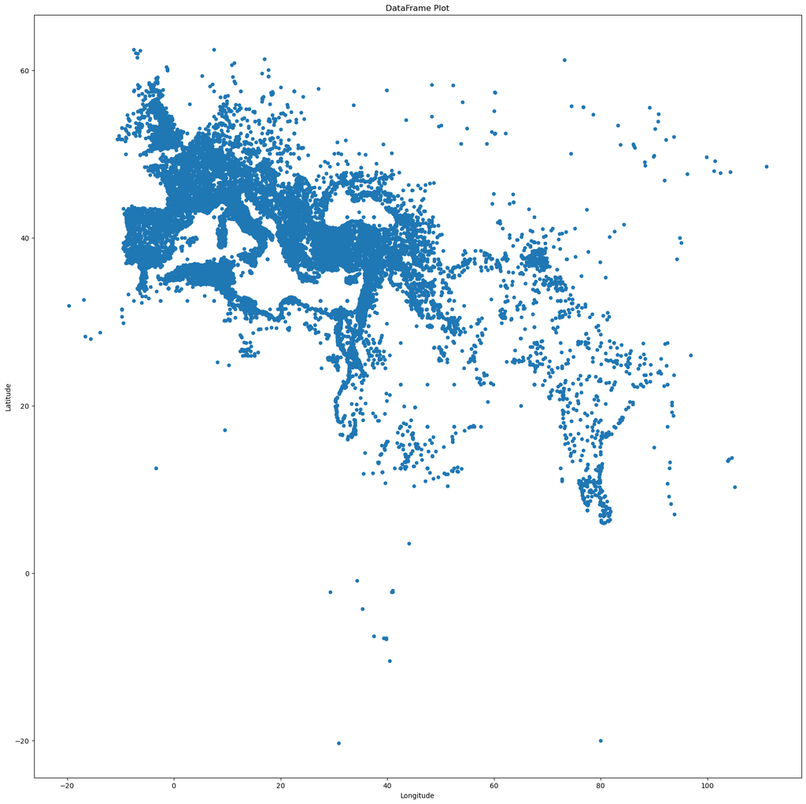

```python
pleiades.plot.scatter(title="DataFrame Plot", y="Latitude", x="Longitude", figsize=(20,20))
```

# POTS

Merging the two Datasets together. I want to create a df sorted by site, with information on the amount of imported and exported pottery in each site.

```python
# making a prelimary empty dataframe for my sites
sites = pd.DataFrame()
```

I wanted at most two decimal places for the Latitude and Longitude data, and so had to round them in both datasets in order to get the data to match up. 42.37641 and 42.37643 are practically same longitude for example (the fifth decimal place is 1.1 m apart) so I make them both 42.37.

```python
bapd = bapd.round({'Latitude': 2, 'Longitude': 2})
#bapd.head()
```

```python
pleiades = pleiades.round({'Latitude': 2, 'Longitude': 2})
#pleiades.head()
```

Joining the BAPD data with the Pleiades data. I wanted an inner join because I only wanted pots that I had lat/long data for, so the lat/long data had to exist in the BAPD data and then have a correlated site in Pleiades.

```python
merged = pd.merge(bapd[['Fabric', 'Country', 'Provenance', 'Date', 'Latitude', 'Longitude']],pleiades[['id', 'Latitude', 'Longitude', 'pid']],on=['Latitude', 'Longitude'], how='inner')
display(merged)
```

|  | Fabric | Country | Provenance | Date | Latitude | Longitude | id | pid |
| --- | --- | --- | --- | --- | --- | --- | --- | --- |
| 0 | ATHENIAN | ITALY | ITALY, ETRURIA, TARQUINIA | -550 to -500 | 42.25 | 11.76 | darmc-location-3586 | /places/413332 |
| 1 | ATHENIAN | ITALY | ITALY, ETRURIA, TARQUINIA | -550 to -500 | 42.25 | 11.76 | darmc-location-18918 | /places/413332 |
| 2 | ATHENIAN | ITALY | ITALY, ETRURIA, TARQUINIA | -550 to -500 | 42.25 | 11.76 | dare-location | /places/413332 |
| 3 | ATHENIAN | ITALY | ITALY, ETRURIA, TARQUINIA | -550 to -500 | 42.25 | 11.76 | darmc-location-3586 | /places/413332 |
| 4 | ATHENIAN | ITALY | ITALY, ETRURIA, TARQUINIA | -550 to -500 | 42.25 | 11.76 | darmc-location-18918 | /places/413332 |
| ... | ... | ... | ... | ... | ... | ... | ... | ... |
| 26600 | ATHENIAN | GERMANY | GERMANY, IPF | -525 to -475 | 48.87 | 10.36 | dare-location | /places/118763 |
| 26601 | ATHENIAN | GERMANY | GERMANY, IPF | -550 to -500 | 48.87 | 10.36 | darmc-location-12885 | /places/118763 |
| 26602 | ATHENIAN | GERMANY | GERMANY, IPF | -550 to -500 | 48.87 | 10.36 | dare-location | /places/118763 |
| 26603 | ATHENIAN | GERMANY | GERMANY, IPF | -525 to -475 | 48.87 | 10.36 | darmc-location-12885 | /places/118763 |
| 26604 | ATHENIAN | GERMANY | GERMANY, IPF | -525 to -475 | 48.87 | 10.36 | dare-location | /places/118763 |

26605 rows × 8 columns

### coordinates

```python
places = merged['pid'].unique()
#places
```

```python
merged['coords'] = merged.apply(lambda row: str(row.Latitude) + " " + str(row.Longitude), axis=1)
```

```python
merged.head()
```

|  | Fabric | Country | Provenance | Date | Latitude | Longitude | id | pid | coords |
| --- | --- | --- | --- | --- | --- | --- | --- | --- | --- |
| 0 | ATHENIAN | ITALY | ITALY, ETRURIA, TARQUINIA | -550 to -500 | 42.25 | 11.76 | darmc-location-3586 | /places/413332 | 42.25 11.76 |
| 1 | ATHENIAN | ITALY | ITALY, ETRURIA, TARQUINIA | -550 to -500 | 42.25 | 11.76 | darmc-location-18918 | /places/413332 | 42.25 11.76 |
| 2 | ATHENIAN | ITALY | ITALY, ETRURIA, TARQUINIA | -550 to -500 | 42.25 | 11.76 | dare-location | /places/413332 | 42.25 11.76 |
| 3 | ATHENIAN | ITALY | ITALY, ETRURIA, TARQUINIA | -550 to -500 | 42.25 | 11.76 | darmc-location-3586 | /places/413332 | 42.25 11.76 |
| 4 | ATHENIAN | ITALY | ITALY, ETRURIA, TARQUINIA | -550 to -500 | 42.25 | 11.76 | darmc-location-18918 | /places/413332 | 42.25 11.76 |

```python
all_coords = merged['coords'].unique()
c = pd.Series(all_coords)
sites["LatLong"] = c
```

```python
display(sites)
```

|  | LatLong |
| --- | --- |
| 0 | 42.25 11.76 |
| 1 | 41.1 14.22 |
| 2 | 32.54 20.57 |
| 3 | 42.72 12.11 |
| 4 | 45.35 36.47 |
| ... | ... |
| 224 | 37.73 -3.05 |
| 225 | 41.89 12.49 |
| 226 | 46.35 11.02 |
| 227 | 45.41 11.88 |
| 228 | 48.87 10.36 |

229 rows × 1 columns

### mark as import/local

- I create an empty column of if something is an import or not
- loop through every single row and identify the fabric and the country of the site found
- define what fabrics are italian and which are greek (this will be more specific in final dataset)
- if a fabric comes from the same country the pot was found in then it is not imported and is locally produced
- else it is an import
- add the bool value for if it is an import to the import column

```python
merged["Import"] = ""
for index, row in merged.iterrows():
    fab = row["Fabric"]
    country = row["Country"]
    imp = True

    italian_fabs = ['ETRUSCAN',
                    'SOUTH ITALIAN, LUCANIAN', 'ITALIOTE', 'SOUTH ITALIAN, APULIAN',
                    'SOUTH ITALIAN, GNATHIAN', 'CUMAEAN',
                    'ITALO-GEOMETRIC', 'VILLA NOVA', 'SOUTH ITALIAN', 'SOUTH ITALIAN, CAMPANIAN',
                    'DAUNIAN', 'PEUCETIAN', 'SOUTH ITALIAN, PAESTAN', 'TEANO WARE']

    greek_fabs = ['ATHENIAN', 'PROTOCORINTHIAN', 'ITALO-CORINTHIAN', 'CHALCIDIAN',
                  'HELLENISTIC', 'LACONIAN', 'LACONIAN GEOMETRIC', 'SUBGEOMETRIC', 'MYCENEAN', 'ATHENIAN (?)',
                  'NORTH GREEK']

    if country == "ITALY" and ("ITAL" in fab or "ETRUCAN" in fab):
        imp = False
    elif country == "GREECE" and fab in greek_fabs:
        imp = False
    merged.loc[index, 'Import'] = imp
```

```python
display(merged)
```

|  | Fabric | Country | Provenance | Date | Latitude | Longitude | id | pid | coords | Import |
| --- | --- | --- | --- | --- | --- | --- | --- | --- | --- | --- |
| 0 | ATHENIAN | ITALY | ITALY, ETRURIA, TARQUINIA | -550 to -500 | 42.25 | 11.76 | darmc-location-3586 | /places/413332 | 42.25 11.76 | True |
| 1 | ATHENIAN | ITALY | ITALY, ETRURIA, TARQUINIA | -550 to -500 | 42.25 | 11.76 | darmc-location-18918 | /places/413332 | 42.25 11.76 | True |
| 2 | ATHENIAN | ITALY | ITALY, ETRURIA, TARQUINIA | -550 to -500 | 42.25 | 11.76 | dare-location | /places/413332 | 42.25 11.76 | True |
| 3 | ATHENIAN | ITALY | ITALY, ETRURIA, TARQUINIA | -550 to -500 | 42.25 | 11.76 | darmc-location-3586 | /places/413332 | 42.25 11.76 | True |
| 4 | ATHENIAN | ITALY | ITALY, ETRURIA, TARQUINIA | -550 to -500 | 42.25 | 11.76 | darmc-location-18918 | /places/413332 | 42.25 11.76 | True |
| ... | ... | ... | ... | ... | ... | ... | ... | ... | ... | ... |
| 26600 | ATHENIAN | GERMANY | GERMANY, IPF | -525 to -475 | 48.87 | 10.36 | dare-location | /places/118763 | 48.87 10.36 | True |
| 26601 | ATHENIAN | GERMANY | GERMANY, IPF | -550 to -500 | 48.87 | 10.36 | darmc-location-12885 | /places/118763 | 48.87 10.36 | True |
| 26602 | ATHENIAN | GERMANY | GERMANY, IPF | -550 to -500 | 48.87 | 10.36 | dare-location | /places/118763 | 48.87 10.36 | True |
| 26603 | ATHENIAN | GERMANY | GERMANY, IPF | -525 to -475 | 48.87 | 10.36 | darmc-location-12885 | /places/118763 | 48.87 10.36 | True |
| 26604 | ATHENIAN | GERMANY | GERMANY, IPF | -525 to -475 | 48.87 | 10.36 | dare-location | /places/118763 | 48.87 10.36 | True |

26605 rows × 10 columns

### ceramic counts

Make separate Latitude and Longitude columns:

```python
sites["Latitude"] = ""
sites["Longitude"] = ""

for index, row in sites.iterrows():
    co = row["LatLong"].split()
    sites.loc[index, 'Latitude'] = co[0]
    sites.loc[index, 'Longitude'] = co[1]
```

Get the total number of pots at each coordinate:

```python
sites["total_pots"] = ""
for index, row in sites.iterrows():
    co = row["LatLong"] # coordinate of the site
    num = len(merged.loc[merged['coords'] == co]) # length of the subset of the the merged pots df where the pot is at that coordinate
    sites.loc[index, 'total_pots'] = num # adding total number of pots to sites
```

Get the total number of imports and exports at each coordinate:

```python
sites["total_imports"] = ""
sites["total_local"] = ""
for index, row in sites.iterrows():
    co = row["LatLong"]
    cos = merged.loc[merged['coords'] == co]

    imps = len(cos.loc[cos['Import'] == True]) # length of the subset of the the merged pots df where the pot is imported
    sites.loc[index, 'total_imports'] = imps

    exps = len(cos.loc[cos['Import'] == False]) # length of the subset of the the merged pots df where the pot is locally produced
    sites.loc[index, 'total_local'] = exps
```

```python
sites['total_local'].unique() # preliminarily looking at how many pots are produced locally-- expected it to be a bit low...
```

```
array([0, 2, 1, 65, 12, 18, 130, 81, 25, 216, 176, 5, 8, 13, 64, 2628, 4,
       74, 9, 7, 198, 32, 35, 6, 3], dtype=object)
```

Still don't have access to my ports data so I just identified the major ports by hand and classical studies major knowledge and grabbed their coordinates from Pleiades...

```python
major_ports = {"41.89 12.48": "Rome",
               "37.97 23.72": "Athens",
               "41.75 12.28": "Ostia",
               "29.23 71.06": "Alexandria",
               "36.84 10.32": "Carthage",
               "37.90 22.87": "Corinth",
               "41.00 28.96": "Constantinople",
               "42.00 12.10": "Caere",
              }
```

```python
display(sites)
```

|  | LatLong | Latitude | Longitude | total_pots | total_imports | total_local |
| --- | --- | --- | --- | --- | --- | --- |
| 0 | 42.25 11.76 | 42.25 | 11.76 | 1551 | 1551 | 0 |
| 1 | 41.1 14.22 | 41.1 | 14.22 | 319 | 317 | 2 |
| 2 | 32.54 20.57 | 32.54 | 20.57 | 252 | 252 | 0 |
| 3 | 42.72 12.11 | 42.72 | 12.11 | 585 | 584 | 1 |
| 4 | 45.35 36.47 | 45.35 | 36.47 | 1036 | 1036 | 0 |
| ... | ... | ... | ... | ... | ... | ... |
| 224 | 37.73 -3.05 | 37.73 | -3.05 | 1 | 1 | 0 |
| 225 | 41.89 12.49 | 41.89 | 12.49 | 37 | 37 | 0 |
| 226 | 46.35 11.02 | 46.35 | 11.02 | 1 | 1 | 0 |
| 227 | 45.41 11.88 | 45.41 | 11.88 | 8 | 8 | 0 |
| 228 | 48.87 10.36 | 48.87 | 10.36 | 10 | 10 | 0 |

229 rows × 6 columns

make my numeric data actually numeric

```python
sites.Latitude = pd.to_numeric(sites.Latitude, errors='coerce')
sites.Longitude = pd.to_numeric(sites.Longitude, errors='coerce')
sites.total_pots = pd.to_numeric(sites.total_pots, errors='coerce')
```

### nearest port

Calculate the distance between two latitude and longitude points:

```python
# https://stackoverflow.com/questions/55227963/calculate-distance-from-latitude-longitude-data-from-dataframe-pandas

def haversine_np(lon1, lat1, lon2, lat2):
    lon1, lat1, lon2, lat2 = map(np.radians, [lon1, lat1, lon2, lat2])

    dlon = lon2 - lon1
    dlat = lat2 - lat1

    a = np.sin(dlat / 2.0) ** 2 + np.cos(lat1) * np.cos(lat2) * np.sin(dlon / 2.0) ** 2

    c = 2 * np.arcsin(np.sqrt(a))
    km = 6367 * c
    return km
```

Make new columns in site of the nearest port and the distance to it.

For every site: calculate the distance to each port city and determine if it is the closest port city encountered so far. If it is, change the nearest port to be that site and the distance to be that distance.

```python
sites["dist_to_port"] = ""
sites["nearest_port"] = ""
for index, row in sites.iterrows():
    co = row["LatLong"]
    lat = row["Latitude"]
    long = row["Longitude"]


    min = 10000000
    for port_co, port in major_ports.items():
        port_co = port_co.split()
        port_lat = float(port_co[0])
        port_long = float(port_co[1])

        dist = haversine_np(long, lat, port_long, port_lat)

        if dist <= min:
            #print("hi")
            min = dist

            sites.loc[index, 'dist_to_port'] = dist
            sites.loc[index, 'nearest_port'] = port
```

```python
display(sites)
```

|  | LatLong | Latitude | Longitude | total_pots | total_imports | total_local | dist_to_port | nearest_port |
| --- | --- | --- | --- | --- | --- | --- | --- | --- |
| 0 | 42.25 11.76 | 42.25 | 11.76 | 1551 | 1551 | 0 | 39.459656 | Caere |
| 1 | 41.1 14.22 | 41.10 | 14.22 | 319 | 317 | 2 | 169.351926 | Rome |
| 2 | 32.54 20.57 | 32.54 | 20.57 | 252 | 252 | 0 | 631.104011 | Corinth |
| 3 | 42.72 12.11 | 42.72 | 12.11 | 585 | 584 | 1 | 80.014295 | Caere |
| 4 | 45.35 36.47 | 45.35 | 36.47 | 1036 | 1036 | 0 | 776.646205 | Constantinople |
| ... | ... | ... | ... | ... | ... | ... | ... | ... |
| 224 | 37.73 -3.05 | 37.73 | -3.05 | 1 | 1 | 0 | 1185.218326 | Carthage |
| 225 | 41.89 12.49 | 41.89 | 12.49 | 37 | 37 | 0 | 0.827247 | Rome |
| 226 | 46.35 11.02 | 46.35 | 11.02 | 1 | 1 | 0 | 490.984143 | Caere |
| 227 | 45.41 11.88 | 45.41 | 11.88 | 8 | 8 | 0 | 379.348092 | Caere |
| 228 | 48.87 10.36 | 48.87 | 10.36 | 10 | 10 | 0 | 775.334338 | Caere |

229 rows × 8 columns

## some graphs

reduced points from original coordinate set-- wanted to compare with the pleiades europe scatter graph

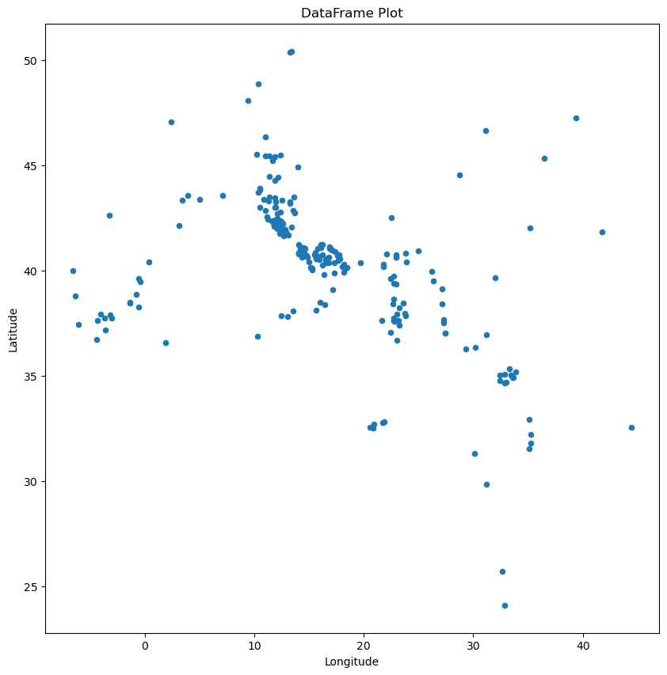

```python
sites.plot.scatter(title="DataFrame Plot", y="Latitude", x="Longitude", figsize=(10,10))
```

This might be because of the strength of the trade system in the mediterranean or just how popular Greek pottery was in non greek area... it also might be because of robust over-land trade happening. More study is needed!

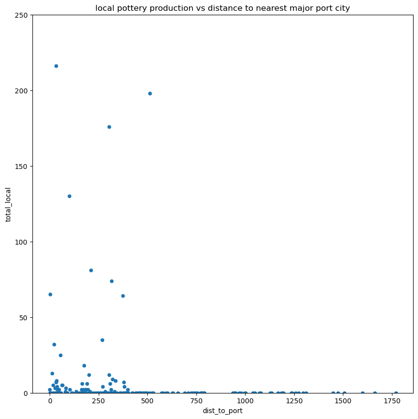

```python
sites.plot.scatter( y="total_local", x="dist_to_port", title="local pottery production vs distance to nearest major port city", ylim=(0,250), figsize=(10,10))
```

Generare pie chart to see, out of all the locally produced potteries, which site had the most produced locally?

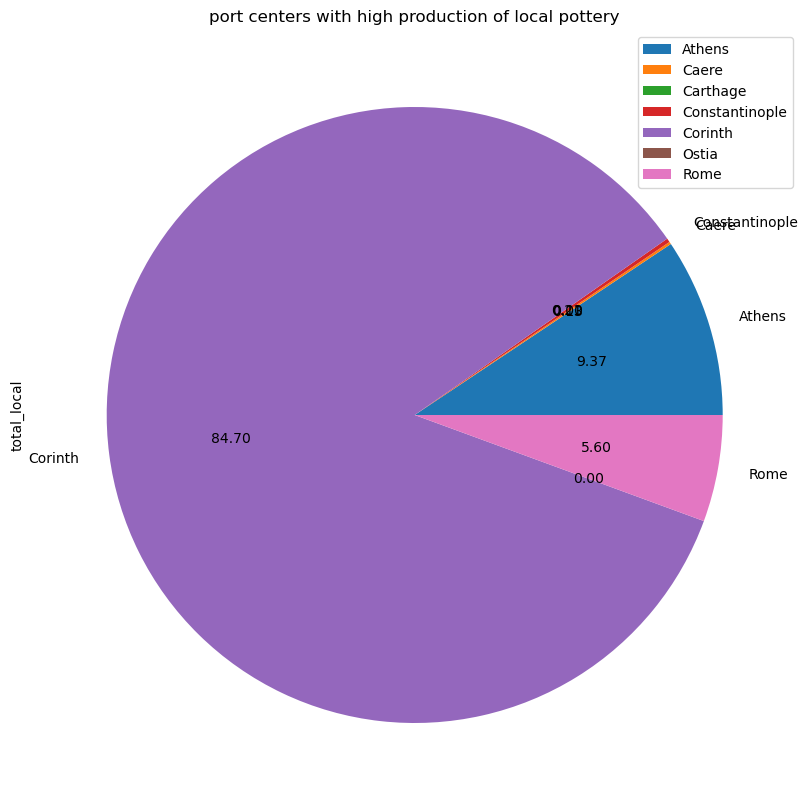

```python
sites.groupby(['nearest_port']).sum().plot(kind='pie', y='total_local', autopct='%.2f', title="port centers with high production of local pottery", figsize=(10, 10))
```

This is what made me realise I need to be factoring in time in my analysis, since the rate of local and imported pottery is dependent on it.

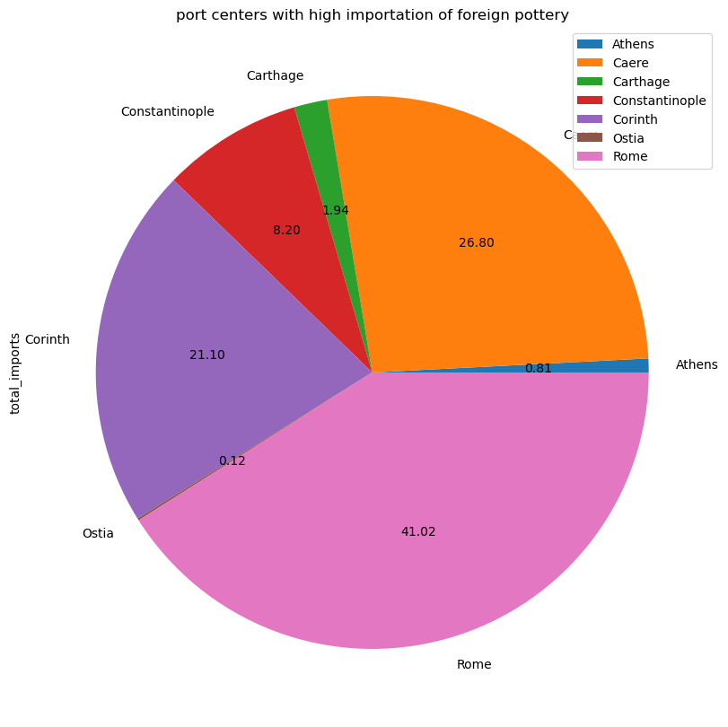

```python
sites.groupby(['nearest_port']).sum().plot(kind='pie', autopct='%.2f', y='total_imports',  title="port centers with high importation of foreign pottery", figsize=(10, 10))
```

## add place name...

use beautifulsoup to find out what the name of a site is, given the pleiades ID

```python
def get_title_from_site(url):
    response = urllib.request.urlopen(url)
    soup = BeautifulSoup(response,
                         'html.parser',
                         from_encoding=response.info().get_param('charset'))

    if soup.findAll("title"):
        return soup.find("title").string.split(":")[0]
    else:
        return
```

Find out how many sub-places are present in each coordinate, get the names of all of them with the get_title_from_site function, and add to a dictionary.

```python
coords_to_places = {}
for i in merged['coords'].unique(): # for every unique coordinate...
    place_ids = merged.loc[merged['coords'] == i]['pid'].unique().tolist() # find the pleiades ids at that coordinate...


    # and make a dictionary of the coordinate to the place ids and the titles of the location
    if len(place_ids) == 1:
        url = f"https://pleiades.stoa.org{place_ids[0]}"
        title = get_title_from_site(url)
        coords_to_places[i] = {'places':place_ids, 'title':title}
    elif len(place_ids) >= 1:
        titles = []
        for id in place_ids:
            url = f"https://pleiades.stoa.org{id}"
            title = get_title_from_site(url)
            titles.append(str(title))
        coords_to_places[i] = {'places':place_ids, 'title':titles}
    print(i, coords_to_places[i])

    #coords_to_places[i] = {'places':x.tolist(), 'title':}
```

```
42.25 11.76 {'places': ['/places/413332'], 'title': 'Tarchna/Tarquinii'}
41.1 14.22 {'places': ['/places/432763'], 'title': 'Casilinum'}
32.54 20.57 {'places': ['/places/373736'], 'title': 'Arsinoe/Taucheira'}
42.72 12.11 {'places': ['/places/413373'], 'title': 'Velzna/*Volsinii Veteres/Urbiventus'}
45.35 36.47 {'places': ['/places/854719'], 'title': 'Pantikapaion/Bosp(h)orus'}
41.06 14.64 {'places': ['/places/432773'], 'title': 'Caudium'}
40.37 16.81 {'places': ['/places/442723'], 'title': 'Pizzica'}
37.98 23.74 {'places': ['/places/582871'], 'title': 'Lykabettos (mountain)'}
34.68 33.04 {'places': ['/places/707587'], 'title': 'Neapolis/Theodosias'}
37.04 27.42 {'places': ['/places/599636', '/places/102024695', '/places/461581651'], 'title': ['Halicarnassus/Halikarnassos', 'Theater at Bodrum', 'Mausoleum at Halicarnassus']}
41.11 14.21 {'places': ['/places/432763', '/places/113170100'], 'title': ['Casilinum', 'Ponte di Capua']}
40.1 18.34 {'places': ['/places/442682'], 'title': 'Muro Leccese'}
40.93 14.53 {'places': ['/places/432981'], 'title': 'Nola'}
41.9 12.48 {'places': ['/places/629324739', '/places/783489695', '/places/635795593', '/places/103808101', '/places/423568', '/places/914715153', '/places/820369854', '/places/820369856', '/places/125119394', '/places/967215409', '/places/503777175', '/places/721487827', '/places/360837130', '/place…
40.85 14.06 {'places': ['/places/832104040', '/places/432808', '/places/282928580'], 'title': ['Porta Mediana necropolis', 'Cumae/Kyme (Campanian)', 'Grotta di Cocceio']}
40.84 14.25 {'places': ['/places/433014'], 'title': 'Parthenope/Neapolis'}
38.11 15.65 {'places': ['/places/631805559', '/places/509519515'], 'title': ['Parco archeologico Griso-Laboccetta', 'Odèon/Ekklesiasterion']}
42.49 12.13 {'places': ['/places/455441008', '/places/674520031', '/places/412987', '/places/413132'], 'title': ['Roman theater at Ferentium', 'Terme Romane, Ferento', 'Acquarossa', 'Ferentium']}
31.78 35.23 {'places': ['/places/687928', '/places/811589743', '/places/937349656'], 'title': ['Ierusalem/Hierosolyma/Col. Aelia Capitolina', 'Church of Saint Alexander Nevsky, Jerusalem', 'Tower of David']}
43.02 11.95 {'places': ['/places/413096'], 'title': 'Clusium'}
37.08 22.42 {'places': ['/places/757663383', '/places/570685'], 'title': ['Roman theater at Sparta', 'Sparta']}
34.77 32.43 {'places': ['/places/707620'], 'title': 'Shyrvallos'}
32.82 21.86 {'places': ['/places/373778', '/places/354239693', '/places/778145952', '/places/778145953', '/places/357884165', '/places/248782117', '/places/163905085', '/places/372376094', '/places/103565779', '/places/529754544', '/places/312715518'], 'title': ['Cyrene', 'So-called Caesareum of Cyr…
42.42 11.87 {'places': ['/places/413356'], 'title': 'Tuscana'}
44.42 12.2 {'places': ['/places/393480', '/places/51062012', '/places/344182764', '/places/344182765', '/places/73180225', '/places/529754545', '/places/122702818'], 'title': ['Ravenna', 'Archiepiscopal Chapel of Ravenna', 'Arian Baptistry', 'New Basilica of Saint Apollinaris', '"Basilica" of San Vi…
39.12 27.18 {'places': ['/places/550874', '/places/956778056', '/places/923431995'], 'title': ['Selinos (river)', 'South Necropolis (Pergamon)', 'Red Basilica']}
34.92 33.62 {'places': ['/places/319430829'], 'title': "Jā' (region)"}
40.75 14.49 {'places': ['/places/256404901', '/places/792436981', '/places/387880487', '/places/524253439', '/places/897019599', '/places/95873554', '/places/379375824', '/places/829196251', '/places/939537684', '/places/999909607', '/places/999909608', '/places/629116433', '/places/600118250', '/pl…
38.46 23.62 {'places': ['/places/540703'], 'title': 'Chalcis'}
37.63 22.72 {'places': ['/places/570106', '/places/84693646', '/places/567146275'], 'title': ['Argos', 'Ancient Agora of Argos', 'Ancient Theater of Argos']}
35.04 32.43 {'places': ['/places/707574'], 'title': 'Marion'}
40.62 14.37 {'places': ['/places/433139'], 'title': 'Surrentum'}
40.42 15.01 {'places': ['/places/375591100', '/places/865200669', '/places/569006287', '/places/103018179', '/places/608476833', '/places/442733', '/places/73180224', '/places/42219804'], 'title': ['Temple of Athena at Paestum', 'Forum of Paestum', 'Roman amphitheater at Paestum', 'Comitium of Posei…
40.64 22.94 {'places': ['/places/630598189', '/places/563800136', '/places/834862589', '/places/170580013'], 'title': ['Temple of Aphrodite (Thessalonica)', 'Church of the Holy Apostles', 'Church of Panagia Chalkeon', 'Church of Saint Catherine, Thessaloniki']}
43.84 10.51 {'places': ['/places/403234'], 'title': 'Luca'}
44.55 28.77 {'places': ['/places/216839'], 'title': 'Histria'}
35.34 33.32 {'places': ['/places/707531'], 'title': 'Keryn(e)ia/Keraunia'}
41.85 41.78 {'places': ['/places/857282'], 'title': 'Pichvnari'}
42.02 12.39 {'places': ['/places/607885597', '/places/486020305', '/places/423116'], 'title': ['Archaeological area of Villa di Campetti', 'Portonaccio sanctuary at Veii', 'Veii']}
43.35 3.44 {'places': ['/places/148135'], 'title': 'La Monédière'}
```

[output cut: 174 more lines]

```
40.65 14.87 {'places': ['/places/442728'], 'title': 'Pontecagnano'}
45.54 10.23 {'places': ['/places/417977726', '/places/740044370', '/places/444468888'], 'title': ['Roman theater at Brixia', 'San Salvatore monastery', 'Capitolium of Brixia']}
37.66 27.3 {'places': ['/places/182750553', '/places/298577312', '/places/599905'], 'title': ['Theater of Priene', 'The Temple of Athena Polias at Priene', 'Priene/‘Lince’?']}
40.74 22.98 {'places': ['/places/491651'], 'title': 'Lete'}
37.18 -3.6 {'places': ['/places/265921'], 'title': 'Iliberri'}
31.31 30.08 {'places': ['/places/727250'], 'title': 'Thonis'}
38.44 -1.33 {'places': ['/places/265943', '/places/872674047'], 'title': ['Jumilla', 'Coimbra del Barranco Ancho']}
37.74 -3.69 {'places': ['/places/265970'], 'title': 'Mentesa Bastia'}
36.72 -4.42 {'places': ['/places/265963', '/places/64187403'], 'title': ['Malaca', 'Roman theater at Malaca']}
37.44 -6.05 {'places': ['/places/556854756', '/places/810966695', '/places/810966696'], 'title': ['Roman amphitheater of Italica', 'Public Square at Italica', 'Collegium at Italica']}
37.73 -3.05 {'places': ['/places/265900'], 'title': 'Fraxinum?'}
41.89 12.49 {'places': ['/places/417632343', '/places/267702570', '/places/267702571', '/places/445192365', '/places/250568480', '/places/445545537', '/places/419380619', '/places/261794683', '/places/285857974', '/places/874299107', '/places/459049147', '/places/47606496', '/places/434423626', '/pl…
46.35 11.02 {'places': ['/places/187471'], 'title': 'Mechel'}
45.41 11.88 {'places': ['/places/393473', '/places/567970830', '/places/967101988', '/places/237512727'], 'title': ['Patavium', 'Ponte di San Lorenzo', 'Ponte Altinate', 'Roman amphitheater at Patavium']}
48.87 10.36 {'places': ['/places/118763'], 'title': 'Ipf'}
```

Now use the dictionary data and add the name(s) and id(s) data for each lat/long coordinate to the sites dataset.

```python
sites["names"] = ""
sites["pid"] = ""
for index, row in sites.iterrows():
    co = row["LatLong"]
    pid = coords_to_places[co]["places"]
    name = coords_to_places[co]["title"]
    #num = len(merged.loc[merged['coords'] == co])
    sites.loc[index, 'pid'] = str(pid)
    sites.loc[index, 'names'] = str(name)
```

```python
display(sites)
```

|  | LatLong | Latitude | Longitude | total_pots | total_imports | total_local | dist_to_port | nearest_port | names | pid |
| --- | --- | --- | --- | --- | --- | --- | --- | --- | --- | --- |
| 0 | 42.25 11.76 | 42.25 | 11.76 | 1551 | 1551 | 0 | 39.459656 | Caere | Tarchna/Tarquinii | ['/places/413332'] |
| 1 | 41.1 14.22 | 41.10 | 14.22 | 319 | 317 | 2 | 169.351926 | Rome | Casilinum | ['/places/432763'] |
| 2 | 32.54 20.57 | 32.54 | 20.57 | 252 | 252 | 0 | 631.104011 | Corinth | Arsinoe/Taucheira | ['/places/373736'] |
| 3 | 42.72 12.11 | 42.72 | 12.11 | 585 | 584 | 1 | 80.014295 | Caere | Velzna/*Volsinii Veteres/Urbiventus | ['/places/413373'] |
| 4 | 45.35 36.47 | 45.35 | 36.47 | 1036 | 1036 | 0 | 776.646205 | Constantinople | Pantikapaion/Bosp(h)orus | ['/places/854719'] |
| ... | ... | ... | ... | ... | ... | ... | ... | ... | ... | ... |
| 224 | 37.73 -3.05 | 37.73 | -3.05 | 1 | 1 | 0 | 1185.218326 | Carthage | Fraxinum? | ['/places/265900'] |
| 225 | 41.89 12.49 | 41.89 | 12.49 | 37 | 37 | 0 | 0.827247 | Rome | ['Basilica Aemilia', 'Santi Giovanni e Paolo',... | ['/places/417632343', '/places/267702570', '/p... |
| 226 | 46.35 11.02 | 46.35 | 11.02 | 1 | 1 | 0 | 490.984143 | Caere | Mechel | ['/places/187471'] |
| 227 | 45.41 11.88 | 45.41 | 11.88 | 8 | 8 | 0 | 379.348092 | Caere | ['Patavium', 'Ponte di San Lorenzo', 'Ponte Al... | ['/places/393473', '/places/567970830', '/plac... |
| 228 | 48.87 10.36 | 48.87 | 10.36 | 10 | 10 | 0 | 775.334338 | Caere | Ipf | ['/places/118763'] |

229 rows × 10 columns

```python
# need to go through and turn multiple names into one name...
# maybe correlate w/ orbis data instead? or do a larger area for lat/long id...
```